# Final Team Notebook

Fucheng Yao, Limei Huang, Eman Nagib, Kwangwoo Kim, Huaiping Wang

## Problem:

> What is the housing price given a certain housing criteria?

### Project impact:

> For owners - understand the value of your property relative to other properties that offer the same features

> For potential investors - assert if the house’s value is reasonable etc.

> For potential buyers/brokers - comparing properties and finding the best value proposition for a certain criteria

## Preparing our dataset:

```r
###############################
# Preparing our dataset table
###############################

kc_housing <- read_csv("../kc_house_data.csv")
kc_houses <- kc_housing %>%
  mutate(transaction_id = row_number()) %>%
  rename("house_id" = id) %>%
  select(transaction_id, everything()) %>%
  separate(date, into = c("year_sold", "month_sold", "day_sold"), sep = "-")

kc_houses$year_sold <- as.numeric(kc_houses$year_sold)
kc_houses$month_sold <- as.numeric(kc_houses$month_sold)
kc_houses$day_sold <- as.numeric(kc_houses$day_sold)

kc_houses <- kc_houses %>% filter(bedrooms != 33)

kc_houses <- kc_houses %>%
  mutate(renovated = ifelse(yr_renovated >0, 1, 0)) %>%
  select(everything(), -yr_renovated)

kc_houses <- kc_houses %>%
  mutate(lat_direction = ifelse(lat >=47.548,"N","S")) %>%
  mutate(long_direction = ifelse(abs(long) >=121.9836,"W","E")) %>%
  mutate(direction=paste(lat_direction,long_direction)) %>%
  select(-c("long","lat","long_direction","lat_direction"))

kc_house_new <- kc_houses %>%
  mutate(SW =ifelse(direction =="S W",1,0)) %>%
  mutate(NW =ifelse(direction =="N W",1,0)) %>%
  mutate(NE =ifelse(direction =="N E",1,0)) %>%
  mutate(SE =ifelse(direction =="S E",1,0)) %>%
  select(-c(direction))

kc_house_new <- kc_house_new %>% mutate(years_old = 2019 - yr_built)

kc_house_new$price <- kc_house_new$price/100000

ddzipcode <- read_excel("zipcode.xlsx")
ddzipcode2 <- ddzipcode %>% select(Zipcode, City)

kc_house_new2 <- left_join(kc_house_new, ddzipcode2, by = c("zipcode" = "Zipcode"))
kc_house_new3 <- kc_house_new2 %>% mutate(city = factor(City)) %>% select(-City)

city <- kc_house_new3 %>% select(city)
city2 <- dummy::dummy(city)

kc_house_new_4 <- cbind(kc_house_new3, city2)
kc_house_new_4 <- kc_house_new_4 %>% filter(bedrooms != 0)

# Table with directions
kc_direction <- kc_house_new_4 %>%
  select(-c(transaction_id,house_id, zipcode,
            year_sold, month_sold, day_sold, yr_built, city, city_Auburn, city_Bellevue,
            city_Black.Diamond, city_Bothell, city_Carnation,
            city_Duvall, city_Enumclaw, city_Fall.City,
            city_Federal.Way, city_Issaquah, city_Kenmore,
            city_Kent, city_Kirkland, city_Maple.Valley,
            city_Medina, city_Mercer.Island, city_North.Bend,
            city_Redmond, city_Renton, city_Sammamish,
            city_Seattle, city_Snoqualmie, city_Vashon,
            city_Woodinville))

#Table with citites
kc_cities <- kc_house_new_4 %>%
  select(-c(transaction_id,house_id, zipcode,
            year_sold, month_sold, day_sold, yr_built, SW, NW, NE, SE))
```

## Data overview:

> Data source: Kaggle - https://www.kaggle.com/harlfoxem/housesalesprediction

> > Our dataset constitute of 41 columns and 21599.

> house_id - Unique ID for each home sold

> Year_sold, month_sold, day_sold - Date of the home sale

> price - Price of each home sold

> bedrooms - Number of bedrooms

> bathrooms - Number of bathrooms, where .5 accounts for a room with a toilet but no shower

> sqft_living - Square footage of the apartments interior living space

> sqft_lot - Square footage of the land space

> floors - Number of floors

> waterfront - A dummy variable for whether the apartment was overlooking the waterfront or not

> view - An index from 0 to 4 of how good the view of the property was

> condition - An index from 1 to 5 on the condition of the apartment

> grade - An index from 1 to 13, where 1-3 falls short of building construction and design, 7 has an average level of construction and design, and 11-13 have a high quality level of construction and design.

> sqft_above - The square footage of the interior housing space that is above ground level

> sqft_basement - The square footage of the interior housing space that is below ground level

> yr_built - The year the house was initially built

> yr_renovated - The year of the house’s last renovation

> zipcode - What zip code area the house is in

> lat - Latitude

> long - Longitude

> sqft_living15 - The square footage of interior housing living space for the nearest 15 neighbors

> sqft_lot15 - The square footage of the land lots of the nearest 15 neighbors

## Descriptive Analyses - explorartory dataset visualizations:

```r
##########################################################################################
#Average House Price Based on Renovation and Grade
##########################################################################################
yao <- kc_house_new %>%
  group_by(renovated,grade) %>%
  summarise(avg_house_price=mean(price)*1000)

reno <- yao[c(3:22),]

reno$renovated <- as.factor(reno$renovated)

format(reno$avg_house_price, scientific=FALSE)
```

```
 [1] " 2102.518" " 2489.192" " 3015.310" " 3992.770" " 5325.886"
 [6] " 7529.802" "10483.777" "14566.119" "21761.434" "34437.000"
[11] " 3300.000" " 2329.783" " 3096.966" " 4871.210" " 7676.190"
[16] "11420.646" "15789.396" "25267.260" "26285.000" "45960.000"
```

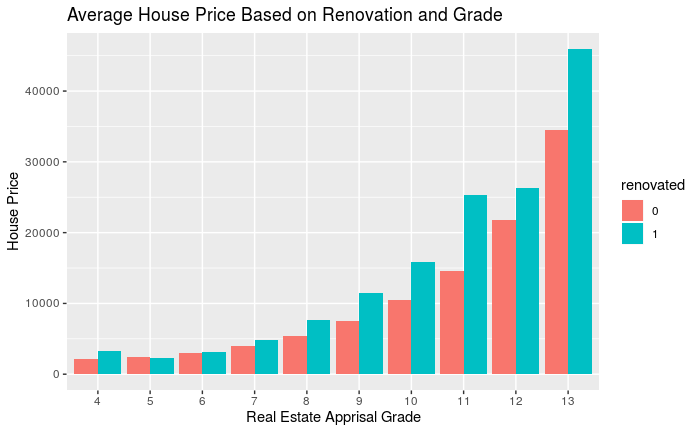

```r
ggplot(reno, aes(factor(grade), avg_house_price, fill = renovated,label=round(avg_house_price,0))) +
  geom_bar(position = "dodge", stat = "identity")  +
  ggtitle("Average House Price Based on Renovation and Grade") +
  ylab("House Price") +
  xlab("Real Estate Apprisal Grade")
```

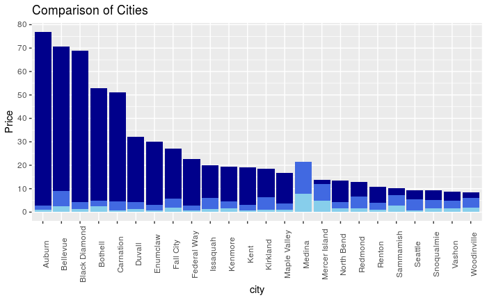

```r
###############################################################################
# city vs. price
###############################################################################

city_price <- kc_house_new_4 %>%
  group_by(city) %>%
  summarize(avg_price = mean(price),
            max_price = max(price),
            min_price = min(price))

col<- c("darkblue" = "Max Price" , "royalblue" = "Average Price", "skyblue" = "Min Price" )
ggplot(city_price) +
  geom_col(aes(city, sort(max_price, decreasing =  T)), fill = "darkblue") +
  geom_col(aes(city, avg_price), fill = "royalblue") +
  geom_col(aes(city, min_price), fill = "skyblue") +
  ggtitle("Comparison of Cities") +
  ylab("Price") +
    scale_colour_manual(name="Line Color", values=c("darkblue", "royalblue", "skyblue"),
                      labels = c("Max Price" , "Average Price", "Min Price" ))+
  theme(axis.text.x = element_text(angle = 90)) +
  scale_y_continuous(breaks = seq(0, 80, 10))
```

[output not shown]

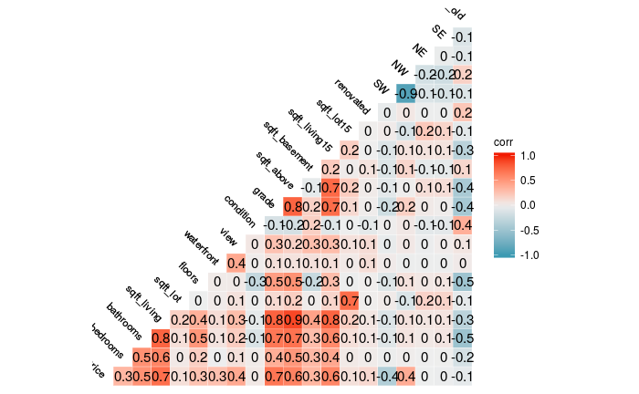

```r
###############################################################################
# best correlations
###############################################################################

#plot correlation
ggcorr(kc_house_new_4 %>% select(-c(transaction_id,house_id, zipcode,
                                    year_sold, month_sold, day_sold, yr_built, city_Auburn, city_Bellevue,
                                    city_Black.Diamond, city_Bothell, city_Carnation,
                                    city_Duvall, city_Enumclaw, city_Fall.City,
                                    city_Federal.Way, city_Issaquah, city_Kenmore,
                                    city_Kent, city_Kirkland, city_Maple.Valley,
                                    city_Medina, city_Mercer.Island, city_North.Bend,
                                    city_Redmond, city_Renton, city_Sammamish,
                                    city_Seattle, city_Snoqualmie, city_Vashon,
                                    city_Woodinville)),
       name = "corr", label = TRUE, hjust = 1,
       abel_size = 2.5, angle = -45, size = 3)
```

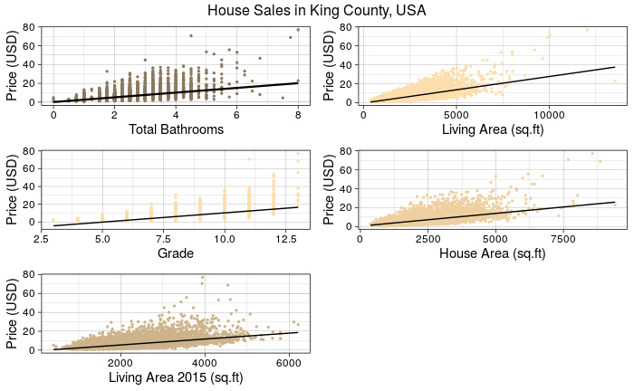

```r
#Linear Plot for attributes with high correlations with price

p1 <- ggplot(kc_house_new_4, aes(x = bathrooms, y = price)) +
  geom_point(color = 'navajowhite4', size = 0.5) +
  geom_smooth(method="lm", color = 'black', size = 0.8) +
  theme_linedraw() +
  labs(x = 'Total Bathrooms', y = 'Price (USD)') +
  scale_y_continuous(labels = scales::comma)

p2 <- ggplot(kc_house_new_4, aes(x = sqft_living, y = price)) +
  geom_point(color = 'navajowhite', size = 0.5) +
  geom_smooth(method="lm", color = 'black', size = 0.5) +
  theme_linedraw() +
  labs(x = 'Living Area (sq.ft)', y = 'Price (USD)') +
  scale_y_continuous(labels = scales::comma)

p3 <- ggplot(kc_house_new_4, aes(x = grade, y = price)) +
  geom_point(color = 'navajowhite1', size = 0.5) +
  geom_smooth(method="lm", color = 'black', size = 0.5) +
  theme_linedraw() +
  labs(x = 'Grade', y = 'Price (USD)') +
  scale_y_continuous(labels = scales::comma)

p4 <- ggplot(kc_house_new_4, aes(x = sqft_above, y = price)) +
  geom_point(color = 'navajowhite2', size = 0.5) +
  geom_smooth(method="lm", color = 'black', size = 0.5) +
  theme_linedraw() +
  labs(x = 'House Area (sq.ft)', y = 'Price (USD)') +
  scale_y_continuous(labels = scales::comma)

p5 <- ggplot(kc_house_new_4, aes(x = sqft_living15, y = price)) +
  geom_point(color = 'navajowhite3', size = 0.5) +
  geom_smooth(method="lm", color = 'black', size = 0.5) +
  theme_linedraw() +
  labs(x = 'Living Area 2015 (sq.ft)', y = 'Price (USD)') +
  scale_y_continuous(labels = scales::comma)

grid.arrange(p1,p2,p3,p4,p5, nrow = 3,
             top = "House Sales in King County, USA")
```

## Set formula for later predictions:

```r
#####################################################
# Set our formula to be used for predictions later
#####################################################

# Formula using the direction dataset
f <- as.formula(price ~ bedrooms + bathrooms + sqft_living + sqft_lot + floors + waterfront +
                  view + condition + grade + sqft_above + sqft_basement + renovated +
                  sqft_living15 + sqft_lot15 + SW + NW + NE + SE, kc_train)

# Formula using the city dataset
f <- as.formula(price ~ bedrooms + bathrooms + sqft_living + sqft_lot + floors + waterfront +
                  view + condition + grade + sqft_above + sqft_basement + renovated +
                  sqft_living15 + sqft_lot15 + city_Auburn + city_Bellevue + city_Black.Diamond +
                  city_Bothell + city_Carnation + city_Duvall + city_Enumclaw + city_Fall.City +
                  city_Federal.Way +city_Issaquah+ city_Kenmore + city_Kent + city_Kirkland + city_Maple.Valley +
                  city_Medina + city_Mercer.Island + city_North.Bend + city_Redmond + city_Renton + city_Sammamish +
                  city_Seattle + city_Snoqualmie + city_Vashon + city_Woodinville, kc_train)
```

## Splitting dataset for train and test:

```r
#####################################################
# Splitting our dataset into test and train
#####################################################
train <- round(0.8 * nrow(kc_cities))
test <- nrow(kc_cities) - train


# spliting data into train and test
set.seed(98765)
train_index <- sample(nrow(kc_cities), train) # get index for random rows

kc_train <- kc_cities[train_index,]
kc_test <- kc_cities[-train_index,]

dim(kc_train)
```

```
[1] 17279    41
```

```r
dim(kc_test)
```

```
[1] 4320   41
```

```r
train <- round(0.8 * nrow(kc_cities))
test <- nrow(kc_cities) - train

x1_train <- model.matrix(f, kc_train)[, -1]
x1_test <- model.matrix(f, kc_test)[, -1]

y_train <- kc_train$price
y_test <- kc_test$price
```

## 1st Method - Linear Regression:

```r
fit_lm <- lm(f, kc_train)

# compute train and test MSEs for the above model:
yhat_train_lm <- predict(fit_lm)
mse_train_lm <- mean((kc_train$price - yhat_train_lm)^2)

yhat_test_lm <- predict(fit_lm, kc_test)
mse_test_lm <- mean((kc_test$price - yhat_test_lm)^2)

#inspect the coefficients of the linear regression model:
coef(fit_lm)
```

```
        (Intercept)            bedrooms           bathrooms
      -5.939906e+00       -3.688291e-01        6.769718e-02
        sqft_living            sqft_lot              floors
       1.615743e-03        2.412004e-06       -1.085323e-01
         waterfront                view           condition
       5.985001e+00        4.787866e-01        4.862089e-01
              grade          sqft_above       sqft_basement
       7.176381e-01        4.647917e-04                  NA
          renovated       sqft_living15          sqft_lot15
       9.819756e-01        2.077758e-04       -3.464404e-06
       city_Auburn1      city_Bellevue1 city_Black.Diamond1
      -1.264440e+00        2.504059e+00       -5.056431e-01
      city_Bothell1     city_Carnation1        city_Duvall1
       2.231078e-02       -5.620201e-02       -3.044477e-01
     city_Enumclaw1     city_Fall.City1   city_Federal.Way1
      -1.230686e+00        4.326978e-01       -1.476451e+00
     city_Issaquah1       city_Kenmore1          city_Kent1
       4.176104e-01        1.459213e-02       -1.114581e+00
     city_Kirkland1  city_Maple.Valley1        city_Medina1
       1.466075e+00       -1.024245e+00        1.126935e+01
city_Mercer.Island1    city_North.Bend1       city_Redmond1
       3.529264e+00       -2.875808e-01        7.431848e-01
       city_Renton1     city_Sammamish1       city_Seattle1
      -5.874842e-01        2.396108e-01        1.378320e+00
   city_Snoqualmie1        city_Vashon1   city_Woodinville1
      -5.415276e-01       -1.117230e+00                  NA
```

```r
# Print MSEs
mse_train_lm
```

```
[1] 3.805245
```

```r
mse_test_lm
```

```
[1] 3.380864
```

## 2nd Method - Lasso:

```r
x_train <- model.matrix(f, kc_train) [ , -1] #Intercept added by default
x_test <- model.matrix(f, kc_test) [ , -1]

# Fit the lasso model
fit_lasso <- cv.glmnet(x_train, kc_train$price, alpha = 1, nfolds = 10)

# compute train/test MSEs
yhat_train_lasso <- predict(fit_lasso, x_train, s = fit_lasso$lambda.min)
mse_train_lasso <- mean((kc_train$y - yhat_train_lasso)^2)

yhat_test_lasso <- predict(fit_lasso, x_test, s = fit_lasso$lambda.min)
mse_test_lasso <- mean((kc_test$y - yhat_test_lasso)^2)

#inspect the coefficients
coef(fit_lasso)
```

```
39 x 1 sparse Matrix of class "dgCMatrix"
                                1
(Intercept)         -5.853943e+00
bedrooms            -7.456046e-02
bathrooms            .
sqft_living          1.654787e-03
sqft_lot             .
floors               .
waterfront           5.120293e+00
view                 4.544908e-01
condition            2.690202e-01
grade                7.996385e-01
sqft_above           6.856744e-05
sqft_basement        .
renovated            5.433445e-01
sqft_living15        1.386405e-04
sqft_lot15           .
city_Auburn1        -9.434346e-01
city_Bellevue1       1.935930e+00
city_Black.Diamond1  .
city_Bothell1        .
city_Carnation1      .
city_Duvall1         .
city_Enumclaw1      -2.202331e-01
city_Fall.City1      .
city_Federal.Way1   -1.151941e+00
city_Issaquah1       .
city_Kenmore1        .
city_Kent1          -8.618756e-01
city_Kirkland1       7.544664e-01
city_Maple.Valley1  -5.342111e-01
city_Medina1         9.210032e+00
city_Mercer.Island1  2.567348e+00
city_North.Bend1     .
city_Redmond1        1.135274e-01
city_Renton1        -3.677540e-01
city_Sammamish1      .
city_Seattle1        9.992701e-01
city_Snoqualmie1     .
city_Vashon1         .
city_Woodinville1    .
```

```r
# Print MSEs
mse_train_lasso
```

```
[1] 2725.409
```

```r
mse_test_lasso
```

```
[1] 2670.081
```

## 3rd Method - Ridge:

```r
x_train <- model.matrix(f, kc_train) [ , -1] #Intercept added by default
x_test <- model.matrix(f, kc_test) [ , -1]

# Fit the lasso model
fit_ridge <- cv.glmnet(x_train, kc_train$price, alpha = 0, nfolds = 10)

# compute train/test MSEs
yhat_train_ridge <- predict(fit_ridge, x_train, s = fit_ridge$lambda.min)
mse_train_ridge <- mean((kc_train$price - yhat_train_lasso)^2)

yhat_test_ridge <- predict(fit_ridge, x_test, s = fit_ridge$lambda.min)
mse_test_ridge <- mean((kc_test$price - yhat_test_lasso)^2)

#inspect the coefficients
coef(fit_ridge)
```

```
39 x 1 sparse Matrix of class "dgCMatrix"
                                1
(Intercept)         -4.770215e+00
bedrooms            -1.343515e-01
bathrooms            2.532795e-01
sqft_living          7.311479e-04
sqft_lot             1.474774e-06
floors               7.655433e-02
waterfront           4.824844e+00
view                 4.948711e-01
condition            3.638453e-01
grade                5.809815e-01
sqft_above           7.338228e-04
sqft_basement        5.947632e-04
renovated            8.911092e-01
sqft_living15        4.933893e-04
sqft_lot15          -1.378217e-06
city_Auburn1        -1.431497e+00
city_Bellevue1       1.617267e+00
city_Black.Diamond1 -7.582275e-01
city_Bothell1       -4.527800e-01
city_Carnation1     -4.375796e-01
city_Duvall1        -7.227164e-01
city_Enumclaw1      -1.343233e+00
city_Fall.City1     -2.718018e-02
city_Federal.Way1   -1.582359e+00
city_Issaquah1      -8.805875e-02
city_Kenmore1       -4.588278e-01
city_Kent1          -1.343688e+00
city_Kirkland1       7.086209e-01
city_Maple.Valley1  -1.269994e+00
city_Medina1         8.603675e+00
city_Mercer.Island1  2.480695e+00
city_North.Bend1    -6.188711e-01
city_Redmond1        2.298121e-01
city_Renton1        -8.962524e-01
city_Sammamish1     -9.923408e-02
city_Seattle1        6.606981e-01
city_Snoqualmie1    -8.380710e-01
city_Vashon1        -1.047991e+00
city_Woodinville1   -3.125821e-01
```

```r
# Print MSEs
mse_train_ridge
```

```
[1] 3.805725
```

```r
mse_test_ridge
```

```
[1] 3.376993
```

## 4th Method - Elastic Net:

```r
x_train <- model.matrix(f, kc_train) [ , -1] #Intercept added by default
x_test <- model.matrix(f, kc_test) [ , -1]

# Fit the lasso model
fit_en <- cv.glmnet(x_train, kc_train$price, alpha = 0.5, nfolds = 10)

# compute train/test MSEs
yhat_train_en<- predict(fit_en, x_train, s = fit_en$lambda.min)
mse_train_en <- mean((kc_train$price - yhat_train_lasso)^2)

yhat_test_en <- predict(fit_en, x_test, s = fit_en$lambda.min)
mse_test_en <- mean((kc_test$price - yhat_test_lasso)^2)

#inspect the coefficients
coef(fit_en)
```

```
39 x 1 sparse Matrix of class "dgCMatrix"
                                1
(Intercept)         -5.9545947820
bedrooms            -0.1432584645
bathrooms            .
sqft_living          0.0015179754
sqft_lot             .
floors               .
waterfront           5.3124880519
view                 0.4772186181
condition            0.3563065465
grade                0.7648030841
sqft_above           0.0002843747
sqft_basement        .
renovated            0.7184106267
sqft_living15        0.0002162639
sqft_lot15           .
city_Auburn1        -1.0997342277
city_Bellevue1       2.0805787155
city_Black.Diamond1  .
city_Bothell1        .
city_Carnation1      .
city_Duvall1         .
city_Enumclaw1      -0.6419510729
city_Fall.City1      .
city_Federal.Way1   -1.2899020217
city_Issaquah1       .
city_Kenmore1        .
city_Kent1          -0.9902569492
city_Kirkland1       0.9650564433
city_Maple.Valley1  -0.7642383693
city_Medina1         9.7948015903
city_Mercer.Island1  2.8517395318
city_North.Bend1     .
city_Redmond1        0.2973045208
city_Renton1        -0.4930967878
city_Sammamish1      .
city_Seattle1        1.0936758611
city_Snoqualmie1    -0.0739912418
city_Vashon1        -0.1199764326
city_Woodinville1    .
```

```r
# Print MSEs
mse_train_en
```

```
[1] 3.805725
```

```r
mse_test_en
```

```
[1] 3.376993
```

## 5th Method - Forward Selection:

```r
## loop
xnames <- colnames(kc_train)
xnames <- xnames[!xnames %in% c("price","transaction_id","house_id", "zipcode",
                                "year_sold", "month_sold", "day_sold", "yr_built", "city")]

fit_fw <- lm(price ~ 1, data = kc_train)

yhat_train <- predict(fit_fw, kc_train)
mse_train <- mean((kc_train$price - yhat_train) ^ 2)

yhat_test <- predict(fit_fw, kc_test)
mse_test <- mean((kc_test$price - yhat_test) ^ 2)

xname <- "intercept"

log_fw <- tibble(
  xname = xname,
  model = paste0(deparse(fit_fw$call), collapse = ""),
  mse_train = mse_train,
  mse_test = mse_test)

while (length(xnames) > 0) {
  best_mse_train <- NA
  best_mse_test <- NA
  best_fit_fw <- NA
  best_xname <- NA

  for (xname in xnames) {
    fit_fw_tmp <- update(fit_fw, as.formula(paste0(". ~ . + ", xname)))
    yhat_train_tmp <- predict(fit_fw_tmp, kc_train)
    mse_train_tmp <- mean((kc_train$price - yhat_train_tmp) ^ 2)
    yhat_test_tmp <- predict(fit_fw_tmp, kc_test)
    mse_test_tmp <- mean((kc_test$price - yhat_test_tmp) ^ 2)

    if (is.na(best_mse_test) | mse_test_tmp < best_mse_test) {
      best_xname <- xname
      best_fit_fw <- fit_fw_tmp
      best_mse_train <- mse_train_tmp
      best_mse_test <- mse_test_tmp
    }
  }
  log_fw <- log_fw %>% add_row(
    xname = best_xname,
    model = paste0(deparse(best_fit_fw$call), collapse = ""),
    mse_train = best_mse_train,
    mse_test = best_mse_test
  )
  fit_fw <- best_fit_fw
  xnames <- xnames[xnames!=best_xname]
}

# Print MSEs
best_mse_train
```

```
[1] 3.624789
```

```r
best_mse_test
```

```
[1] 3.207087
```

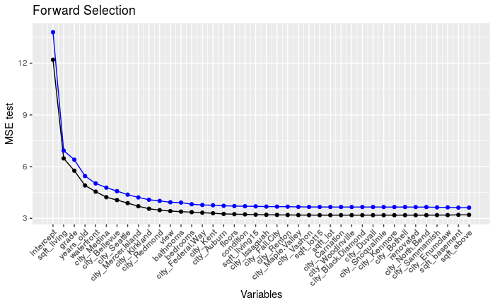

```r
### ggplot
ggplot(log_fw, aes(seq_along(xname), mse_test)) +
  geom_point() +
  geom_line() +
  geom_point(aes(y=mse_train), color="blue") +
  geom_line(aes(y=mse_train), color="blue") +
  ggtitle("Forward Selection")+
  scale_x_continuous("Variables", labels = log_fw$xname, breaks = seq_along(log_fw$xname)) +
  scale_y_continuous("MSE test") +
  theme(axis.text.x = element_text(angle = 45, hjust = 1))
```

## 6th Method - Trees:

```r
fit.tree <- rpart(f,
                  kc_train,
                  control = rpart.control(cp = 0.001))

y_hat_train <- predict(fit.tree, kc_train)
tree_mse_train <- mean((y_hat_train - y_train)^2)

y_hat_test <- predict(fit.tree, kc_test)
tree_mse_test <- mean((y_hat_test - y_test)^2)

# Print MSEs
tree_mse_train
```

```
[1] 3.285627
```

```r
tree_mse_test
```

```
[1] 4.032327
```

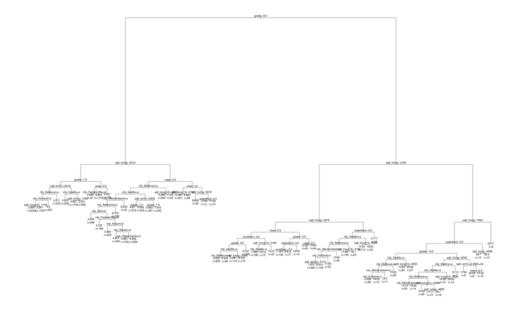

```r
par(xpd = T)
plot(fit.tree, compress=TRUE)
text(fit.tree, use.n=TRUE)
```

## 7th Method - Bagging:

```r
tree_bag <- bagging(f, data=kc_train, coob=TRUE)

y_hat_train <- predict(tree_bag, kc_train)
tree_mse_train_bag <- mean((y_hat_train - y_train)^2)

y_hat_test <- predict(tree_bag, kc_test)
tree_mse_test_bag <- mean((y_hat_test - y_test)^2)

# Print MSEs
tree_mse_train_bag
```

```
[1] 5.102953
```

```r
tree_mse_test_bag
```

```
[1] 5.191094
```

## 8th Method - Random Forest:

```r
xnames <- colnames(kc_cities)
xnames <- xnames[!xnames %in% c("price", "bedrooms", "city")]

loopformula <- " price ~ bedrooms"
for (xname in xnames) {
  loopformula <- paste(loopformula, "+", xname, sep = "")
}

f <- as.formula(loopformula)

fit_rf <- randomForest(f,
                       kc_train,
                       ntree = 10,
                       do.trace = F)

y_hat_train_random <- predict(fit_rf, kc_train)
tree_mse_train_random <- mean((y_hat_train_random - y_train)^2)
y_hat_test_random <- predict(fit_rf, kc_test)
tree_mse_test_random <- mean((y_hat_test_random - y_test)^2)

# Print MSEs
tree_mse_train_random
```

```
[1] 0.6316882
```

```r
tree_mse_test_random
```

```
[1] 2.793773
```

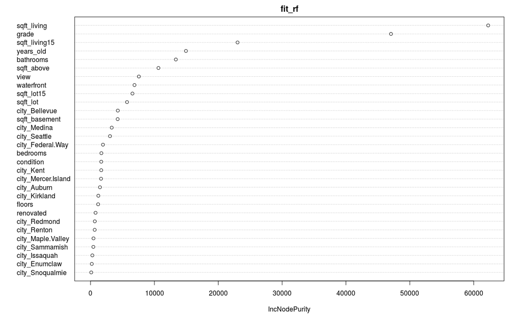

```r
varImpPlot(fit_rf)
```

## 9th Method - Boosting:

```r
fit_btree <- gbm(f,
                 data = kc_train,
                 distribution = "gaussian",
                 n.trees = 1500,
                 interaction.depth = 4,
                 shrinkage = 0.001)

relative.influence(fit_btree)
```

```
n.trees not given. Using 1500 trees.
          bedrooms          bathrooms        sqft_living
          1208.776         125616.855       16911505.427
          sqft_lot             floors         waterfront
          4285.566              0.000        1690789.002
              view          condition              grade
        751843.175              0.000       14819540.766
        sqft_above      sqft_basement      sqft_living15
        503382.391              0.000         357455.633
        sqft_lot15          renovated          years_old
          3558.657              0.000        1849084.097
       city_Auburn      city_Bellevue city_Black.Diamond
             0.000         319085.787              0.000
      city_Bothell     city_Carnation        city_Duvall
             0.000              0.000              0.000
     city_Enumclaw     city_Fall.City   city_Federal.Way
             0.000              0.000              0.000
     city_Issaquah       city_Kenmore          city_Kent
             0.000              0.000           1235.066
     city_Kirkland  city_Maple.Valley        city_Medina
             0.000              0.000         280979.811
city_Mercer.Island    city_North.Bend       city_Redmond
             0.000              0.000              0.000
       city_Renton     city_Sammamish       city_Seattle
             0.000              0.000          22980.432
   city_Snoqualmie        city_Vashon   city_Woodinville
             0.000              0.000              0.000
```

```r
y_hat_train_boosting <- predict(fit_btree, kc_train, n.trees = 100)
tree_mse_train_boosting <- mean((y_hat_train_boosting - y_train)^2)

y_hat_test_boosting <- predict(fit_btree, kc_test, n.trees = 100)
tree_mse_test_boosting <- mean((y_hat_test_boosting - y_test)^2)

# Print MSEs
tree_mse_train_boosting
```

```
[1] 12.51521
```

```r
tree_mse_test_boosting
```

```
[1] 11.04487
```

```r
#Generating a Prediction matrix for each Tree
n.trees = seq(from=1 ,to=1500, by=10)
predmatrix<-predict(fit_btree, kc_train, n.trees = n.trees)

#Calculating The Mean squared Test Error
#contains the Mean squared test error for each of the 100 trees averaged
train.error <- with(kc_train, apply( (predmatrix- y_train)^2,2,mean))

#Plotting the test errors
par(xpd=FALSE)
plot(n.trees , train.error , pch=19,col="blue",xlab="Number of Trees",
     ylab="Test MSE", main = "Perfomance of Boosting on Test Set VS. Other Methods",ylim = c(0, 15))

abline(h = min(tree_mse_test_random),col="maroon") #test.err is the test error of a Random forest fitted on same data
```

```r
abline(h = min(tree_mse_test_bag),col="green")
abline(h = min(tree_mse_test),col="purple")
```

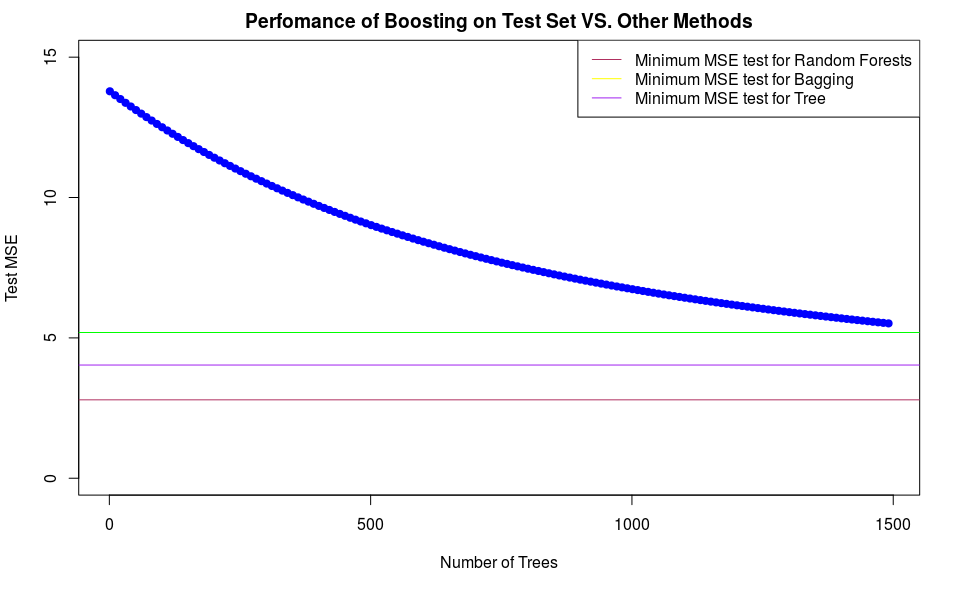

```r
legend("topright",c("Minimum MSE test for Random Forests", "Minimum MSE test for Bagging",
                    "Minimum MSE test for Tree"),col= c("maroon", "yellow", "purple"),lty=1,lwd=1)
```